# Half Pounder GSI

```r
require(adegenet)
require(tidyverse)
require(magrittr)
require(rubias)
```

# Rationale

Here we attempt to assess rate at which rogue halfpounders stray from other rivers. We assign halfpounders using rubias GSI to Klamath Basin Region or Rogue region using empirical data from this project for the Rogue baseline and samples shared from Devon Pearse for the Klamath Region.

# Baseline Samples

**Klamath Baseline**  
The full CA baseline contains 2744 fish genotyped at 90 loci. Coastal samples are distributed from Smith River near the OR-CA border to Big Sur River in the South.

We only include 212 samples from the region where halfpounders are known to occur, from the Eel River north.

```r
# import baseline data
full_CA_baseline <- read_csv("Omykiss_SNPbaseline_Donohoe_etal_2021.csv")

# keep only Klamath region samples
ncal_baseline <- full_CA_baseline %>%
  slice_head( n = 212)

# add population names
ncal_baseline %<>%
  mutate(pop = str_extract(indiv, "^[:alpha:]+"))

ncal_baseline %>%
  count(pop)
```

|  | pop | n |
| --- | --- | --- |
| 1 | BlKlaRi | 32 |
| 2 | BlMadRi | 31 |
| 3 | HoEelRi | 28 |
| 4 | HuKlaRi | 28 |
| 5 | LaEelRi | 30 |
| 6 | LstMaCk | 31 |
| 7 | SmithRi | 32 |

From North to South these rivers are:

Smith River - SmithRi Blue Creek, Klamath River - BlKlaRi Hunter Creek, Klamath River - HuKlaRi Lost Man Creek / Redwood Creek - LstMaCk Mad River - BlMadRi Hollow Tree Creek, Eel River - HoEelRi Lawrence Creek, Eel River - LaEelRi

For GSI we will group all of these samples into a “reporting region” called “Klamath Region”

**Rogue Baseline**

For the Rogue river baseline we we randomly sample an equal number of adults from the Rogue river.

```r
#run this only once and save output so that each knitr rendering doesn't creat a new sample
load("../genotype_data_2021/genind_2.0.R")
load("../genotype_data_2021/genotypes_2.2.R")
genos_2.3 <- genos_2.2
genind_2.1 <- genind_2.0
genos_2.3 <- ungroup(genos_2.3)

rogue_baseline_samples <- genos_2.3 %>%
  filter(run != "halfpounder") %>%
  sample_n(size = 212) %>%
  pull(Sample)

save(rogue_baseline_samples, file = "rogue_baseline_samples.R")
```

```r
load("../genotype_data_2021/genind_2.0.R")
load("../genotype_data_2021/genotypes_2.2.R")
genos_2.3 <- genos_2.2
genind_2.1 <- genind_2.0
genos_2.3 <- ungroup(genos_2.3)

load("rogue_baseline_samples.R")
rogue_baseline_full_genos <- genos_2.3 %>%
  filter(Sample %in% rogue_baseline_samples)

rogue_baseline_full_genos %>%
  count(run)
```

|  | run | n |
| --- | --- | --- |
| 1 | fall | 161 |
| 2 | Summer | 26 |
| 3 | Winter | 25 |

# GSI loci overlap

How many loci are shared between the baseline data from California and our GTseq panel? When we compared the mansucript from which the baseline was based (Adabía-Cardoso 2011) with our GTseq panel, 58 markers overlapped.

```r
#convert column names
cols_cal <- str_replace(colnames(ncal_baseline), "^SH", "Omy_")

sum(colnames(rogue_baseline_full_genos) %in% cols_cal)
```

```
## [1] 45
```

```r
colnames(rogue_baseline_full_genos)[colnames(rogue_baseline_full_genos) %in% cols_cal]
```

```
##  [1] "OMGH1PROM1-SNP1" "Omy_101554-306"  "Omy_101832-195"  "Omy_101993-189"
##  [5] "Omy_102505-102"  "Omy_103705-558"  "Omy_104519-624"  "Omy_105075-162"
##  [9] "Omy_105105-448"  "Omy_105385-406"  "Omy_105714-265"  "Omy_107285-69"
## [13] "Omy_109243-222"  "Omy_109525-403"  "Omy_110064-419"  "Omy_110201-359"
## [17] "Omy_110362-585"  "Omy_110689-148"  "Omy_111666-301"  "Omy_112301-202"
## [21] "Omy_112820-82"   "Omy_114315-438"  "Omy_114587-480"  "Omy_114976-223"
## [25] "Omy_116733-349"  "Omy_117286-374"  "Omy_117370-400"  "Omy_117540-259"
## [29] "Omy_117815-81"   "Omy_118175-396"  "Omy_118654-91"   "Omy_120255-332"
## [33] "Omy_129870-756"  "Omy_130524-160"  "Omy_131460-646"  "Omy_96222-125"
## [37] "Omy_97077-73"    "Omy_97954-618"   "Omy_98683-165"   "Omy_99300-202"
## [41] "Omy_arp-630"     "Omy_aspAT-123"   "Omy_g12-82"      "Omy_gh-475"
## [45] "Omy_mapK3-103"
```

Only 45 markers overlap in the actual filtered datasets.

Let’s make the mixture (test) and reference dataset, by filtering the Rogue and NCal data by shared markers.

```r
shared_markers <- colnames(rogue_baseline_full_genos)[colnames(rogue_baseline_full_genos) %in% cols_cal]
shared_markers <- c(shared_markers, paste(shared_markers, "1", sep = "_"))

colnames(ncal_baseline) <- str_replace(colnames(ncal_baseline), "^SH", "Omy_")

ncal_shared <- ncal_baseline %>%
  select(indiv, pop, one_of(shared_markers))

rogue_baseline <- rogue_baseline_full_genos %>%
  select(Sample, run, one_of(shared_markers))

# Next we need to make some changes to the Rogue dataset (nucleotide to integer, once column per allele etc)

#write_tsv(rogue_baseline, "rogue_baseline.txt")
#made changes using regex in a text editor
# first split columns of genotype data
# then duplicated headers: find: ([a-zA-Z0-9\-_]+), replace: \1\t\1_1

rogue_baseline <- read_tsv("rogue_baseline.txt")
#oops a column is all Ts so it got interepreted at a logical lets fix this
rogue_baseline$`Omy_117286-374_1` <- rep("T", 212)

#correct headers for rubias
rogue_baseline %<>%
  rename(indiv = Sample, collection = run)

#convert to integer code
#inferred code by comparing alleles across datasets:
# 1-T
# 2-G
# 3-C
# 4-A

rogue_baseline %<>%
  mutate(across(everything(), as.character)) %>%
  mutate(across(-one_of(c("indiv", "collection")), ~ case_when(. == "T" ~ "1",
                                                      . == "G" ~ "2",
                                                      . == "C" ~ "3",
                                                      . == "A" ~ "4")))

ncal_shared %<>%
  rename(collection = pop)

ncal_shared %<>%
  mutate(across(everything(), as.character))

#now make the baseline
baseline <- bind_rows(rogue_baseline, ncal_shared, .id = "repunit")

baseline %<>%
  mutate(repunit = case_when(repunit == "1" ~ "Rogue",
                             repunit =="2" ~ "Klamath"))

baseline$sample_type <- rep("reference", 424)

baseline %<>%
  relocate(sample_type)

# save as file
#write_tsv(baseline, "final_baseline.txt")
```

```r
baseline_data <- read_tsv("final_baseline.txt")
baseline_data %<>%
  mutate(across(everything(), as.character))
```

# Power/Accuracy Simulation

Next we run some simulations using the reference dataset to asses the accuracy and power of the baseline to correctly assign the halfpounders.

## Reference Self-Assignment

First we attempt self-assignment of reference samples to their reporting group (ie Klamath region or Rogue)

```r
sa <- self_assign(reference = baseline_data, gen_start_col = 5)
```

```
## Summary Statistics:
##
## 424 Individuals in Sample
##
## 45 Loci: OMGH1PROM1-SNP1, Omy_101554-306, Omy_101832-195, Omy_101993-189, Omy_102505-102, Omy_103705-558, Omy_104519-624, Omy_105075-162, Omy_105105-448, Omy_105385-406, Omy_105714-265, Omy_107285-69, Omy_109243-222, Omy_109525-403, Omy_110064-419, Omy_110201-359, Omy_110362-585, Omy_110689-148, …
##
## 2 Reporting Units: Rogue, Klamath
##
## 10 Collections: fall, Winter, Summer, SmithRi, BlKlaRi, HuKlaRi, LstMaCk, BlMadRi, HoEelRi, LaEelRi
##
## 0.40% of allelic data identified as missing
```

```r
#summarise by reporting unit
sa_to_repu <- sa %>%
  group_by(indiv, collection, repunit, inferred_repunit) %>%
  summarise(repu_scaled_like = sum(scaled_likelihood))
# for each individual, assign to most likely reporting unit
sa_assign <- sa_to_repu %>%
  group_by(indiv) %>%
  slice_max(repu_scaled_like)

sa_assign$correct_assignment <- sa_assign$repunit == sa_assign$inferred_repunit

sum(sa_assign$correct_assignment/nrow(sa_assign))
```

```
## [1] 1
```

Self-assignment assigns (maximum scaled likelihood) reference individuals back to correct reporting unit 100% of time.

## Simulated Mixture

While we can successfully assign reference individuals back to the correct reporting unit, what about a simulated mixture? Also We have some priors about the Rogue samples, specifically we assume that the number of stray is relatively small relative to fish returning to natal reporting units (Klamath vs Rogue). Let’s try both

### 1:1 mixture proportion

First let’s assume halfpounders are equally represented across the reporting units.

Here we conduct a 500 simulations of a mixture of 200 samples drawn at equal rates from the reporting units.

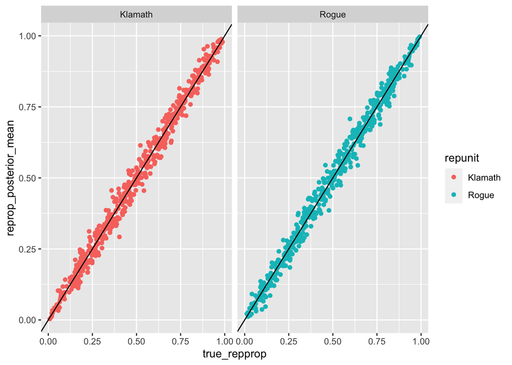

```r
ref_sims_no_prior <- assess_reference_loo(reference = baseline_data,
                     gen_start_col = 5,
                     reps = 500,
                     mixsize = 200,
                     )

tmp <- ref_sims_no_prior %>%
  group_by(iter, repunit) %>%
  summarise(true_repprop = sum(true_pi),
            reprop_posterior_mean = sum(post_mean_pi),
            repu_n = sum(n)) %>%
  mutate(repu_n_prop = repu_n / sum(repu_n))

ggplot(tmp, aes(x = true_repprop, y = reprop_posterior_mean, colour = repunit)) +
  geom_point() +
  geom_abline(intercept = 0, slope = 1) +
  facet_wrap(~ repunit)
```

Using equal priors acorss the two reporting units the true vs inferred mixture proprotions (above) show very small residuals.

Now let’s check how reliable an individual assignment (posterior probability) is from these simulations.

```r
ref_sims_no_prior_indivs <- assess_reference_loo(reference = baseline_data,
                     gen_start_col = 5,
                     reps = 500,
                     mixsize = 200,
                     return_indiv_posteriors = TRUE)

# summarise things
repu_pofzs <- ref_sims_no_prior_indivs$indiv_posteriors %>%
  filter(repunit == simulated_repunit) %>%
  group_by(iter, indiv, simulated_collection, repunit) %>%  # first aggregate over reporting units
  summarise(repu_PofZ = sum(PofZ)) %>%
  ungroup() %>%
  arrange(repunit, simulated_collection) %>%
  mutate(simulated_collection = factor(simulated_collection, levels = unique(simulated_collection)))
```

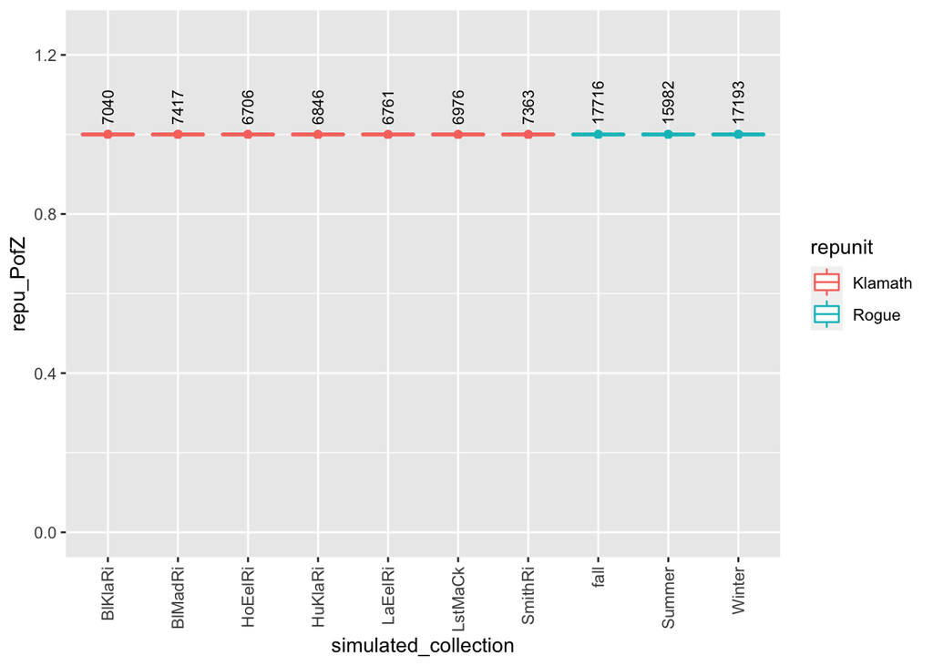

```r
# also get the number of simulated individuals from each collection
num_simmed <- ref_sims_no_prior_indivs$indiv_posteriors %>%
  group_by(iter, indiv) %>%
  slice(1) %>%
  ungroup() %>%
  count(simulated_collection)

# note, the last few steps make simulated collection a factor so that collections within
# the same repunit are grouped together in the plot.

# now, plot it
ggplot(repu_pofzs, aes(x = simulated_collection, y = repu_PofZ)) +
  geom_boxplot(aes(colour = repunit)) +
  geom_text(data = num_simmed, mapping = aes(y = 1.025, label = n), angle = 90, hjust = 0, vjust = 0.5, size = 3) +
  theme(axis.text.x = element_text(angle = 90, hjust = 1, size = 9, vjust = 0.5)) +
  ylim(c(0, 1.25))
```

Perfect assignment to reporting unit within each collection, but am I doing everything correctly here? It seems unlikely to get this level of accuracy. Let’s check assignment back to collection. We know this shouldn’t work, at least for fall rogue fish.

```r
coll_pofzs <- ref_sims_no_prior_indivs$indiv_posteriors %>%
  filter(collection == simulated_collection) %>%
  arrange(repunit, simulated_collection) %>%
  mutate(simulated_collection = factor(simulated_collection, levels = unique(simulated_collection)))
```

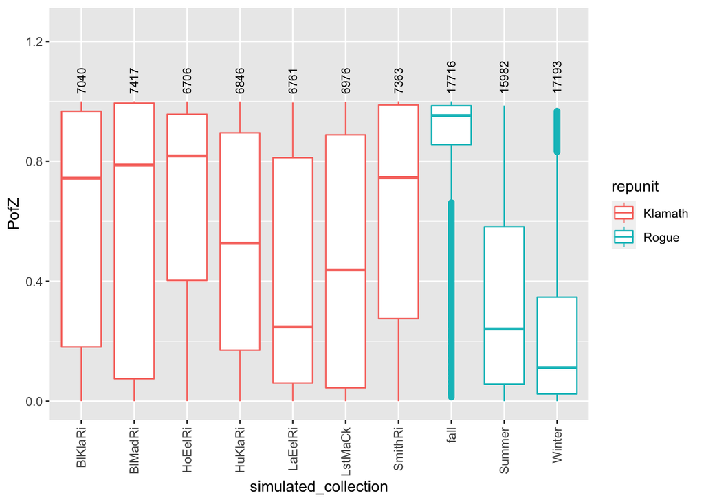

```r
# also get the number of simulated individuals from each collection
num_simmed <- ref_sims_no_prior_indivs$indiv_posteriors %>%
  group_by(iter, indiv) %>%
  slice(1) %>%
  ungroup() %>%
  count(simulated_collection)

# note, the last few steps make simulated collection a factor so that collections within
# the same repunit are grouped together in the plot.

# now, plot it
ggplot(coll_pofzs, aes(x = simulated_collection, y = PofZ)) +
  geom_boxplot(aes(colour = repunit)) +
  geom_text(data = num_simmed, mapping = aes(y = 1.025, label = n), angle = 90, hjust = 0, vjust = 0.5, size = 3) +
  theme(axis.text.x = element_text(angle = 90, hjust = 1, size = 9, vjust = 0.5)) +
  ylim(c(0, 1.25))
```

Okay, posterior means of group membership in each collection is not 1. This comes as a relief. The mean probability that the genotype of an individuals is from the correct collection is 52%.

### 90% Rogue

Now let’s adjust the prior. Let’s assume only a 10% straying rate (instead of 50%) and try again.

```r
#
arep <- data.frame(c("Klamath", "Rogue"), c(0.1, 0.9))
colnames(arep) <- c("repunit", "ppn")

ref_sims <- assess_reference_loo(reference = baseline_data,
                     gen_start_col = 5,
                     reps = 500,
                     mixsize = 200,
                     alpha_repunit = arep,
                     return_indiv_posteriors = TRUE)

# summarise things
repu_pofzs <- ref_sims$indiv_posteriors %>%
  filter(repunit == simulated_repunit) %>%
  group_by(iter, indiv, simulated_collection, repunit) %>%  # first aggregate over reporting units
  summarise(repu_PofZ = sum(PofZ)) %>%
  ungroup() %>%
  arrange(repunit, simulated_collection) %>%
  mutate(simulated_collection = factor(simulated_collection, levels = unique(simulated_collection)))
```

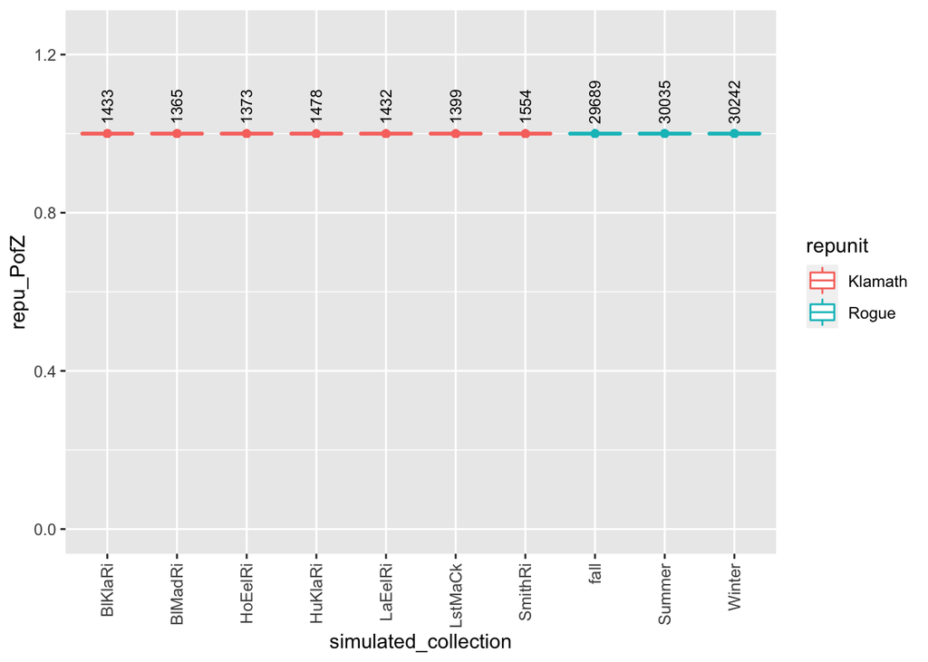

```r
# also get the number of simulated individuals from each collection
num_simmed <- ref_sims$indiv_posteriors %>%
  group_by(iter, indiv) %>%
  slice(1) %>%
  ungroup() %>%
  count(simulated_collection)

# note, the last few steps make simulated collection a factor so that collections within
# the same repunit are grouped together in the plot.

# now, plot it
ggplot(repu_pofzs, aes(x = simulated_collection, y = repu_PofZ)) +
  geom_boxplot(aes(colour = repunit)) +
  geom_text(data = num_simmed, mapping = aes(y = 1.025, label = n), angle = 90, hjust = 0, vjust = 0.5, size = 3) +
  theme(axis.text.x = element_text(angle = 90, hjust = 1, size = 9, vjust = 0.5)) +
  ylim(c(0, 1.25))
```

Still perfect assignment.

Power and accuracy for assignment looks very good let’s move on to GSI.

# GSI

Let’s look for strays. Below we use rubias GSI to conduct three related analyses:  
(1) Estimate the overall straying rate (mixture propotion) from Klamath Basin  
(2) Check for samples that are not from ANY of the reference populations  
(3) Identify individuals where GSI reports the genotype is most likely a stray.

## Klamath vs Rogue Mixture Proportions

What proportion of the Rogue half-pounders are from Klamath the Klamath region

```r
#first get data
half_pounders_GSI_data <- genos_2.3 %>%
  filter(run == "halfpounder") %>%
  select(Sample, run, year, one_of(shared_markers))

write_tsv(half_pounders_GSI_data, "half_pounder_GSI.txt")

#split columns
```

```r
half_pounders_GSI_data <- read_tsv("half_pounder_GSI.txt")
half_pounders_GSI_data$`Omy_117286-374_1` <- rep("T", 643)

#get rid of year
half_pounders_GSI_data %<>%
  select(-year)

#convert to integer code
#inferred code by comparing alleles across datasets:
# 1-T
# 2-G
# 3-C
# 4-A

half_pounders_GSI_data %<>%
  mutate(across(everything(), as.character)) %>%
  mutate(across(-one_of(c("indiv", "collection")), ~ case_when(. == "T" ~ "1",
                                                      . == "G" ~ "2",
                                                      . == "C" ~ "3",
                                                      . == "A" ~ "4")))



#now make the dataset
GSI_data <- bind_rows(baseline_data, half_pounders_GSI_data, .id = "sample_type")

GSI_data %<>%
  mutate(sample_type = case_when(sample_type == "1" ~ "reference",
                             sample_type =="2" ~ "mixture"))

GSI_data_reference <- GSI_data %>%
  filter(sample_type == "reference")

GSI_data_mixture <- GSI_data %>%
  filter(sample_type == "mixture")
```

```r
mix_est <- infer_mixture(reference = GSI_data_reference, mixture = GSI_data_mixture, gen_start_col = 5 )
```

```
## Collating data; compiling reference allele frequencies, etc.   time: 0.26 seconds
## Computing reference locus specific means and variances for computing mixture z-scores   time: 0.02 seconds
## Working on mixture collection: halfpounder with 643 individuals
##   calculating log-likelihoods of the mixture individuals.   time: 0.01 seconds
##   performing 2000 total sweeps, 100 of which are burn-in and will not be used in computing averages in method "MCMC"   time: 0.09 seconds
##   tidying output into a tibble.   time: 0.11 seconds
```

```r
#summarize by reporting unit
mix_est$mixing_proportions %>%
  group_by(repunit) %>%
  summarise(half_pounder_mixing_prop = sum(pi))
```

|  | repunit | half_pounder_mixing_prop |
| --- | --- | --- |
| 1 | Klamath | 0.001058418 |
| 2 | Rogue | 0.998941582 |

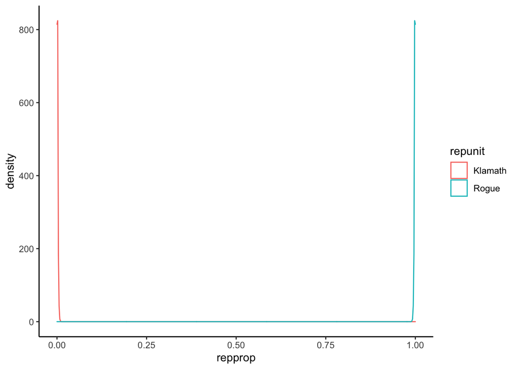

```r
#plot the posterior densitites of the mixing proportions (discarding the first 200 sweeps as a burn in)
trace_subset <- mix_est$mix_prop_traces %>%
  filter(mixture_collection == "halfpounder", sweep > 200) %>%
  group_by(sweep, repunit) %>%
  summarise(repprop = sum(pi))
ggplot(trace_subset, aes(x = repprop, colour = repunit)) +
  geom_density()+theme_classic()
```

```r
#next get some number out of this plot, estimate 95% credible intervals for the mixing proportions
cis <- trace_subset %>%
  group_by(repunit) %>%
  summarise(loCI = quantile(repprop, probs = 0.025),
            hiCI = quantile(repprop, probs = 0.975))

cis
```

|  | repunit | loCI | hiCI |
| --- | --- | --- | --- |
| 1 | Klamath | 5.750498e-06 | 0.004534572 |
| 2 | Rogue | 9.954654e-01 | 0.999994250 |

## Other system

Here we check the z scores to see if any of the individual assignment are very weak, indicating that a halfpounder may be a stray, but that from a region other than Rogue or Klamath

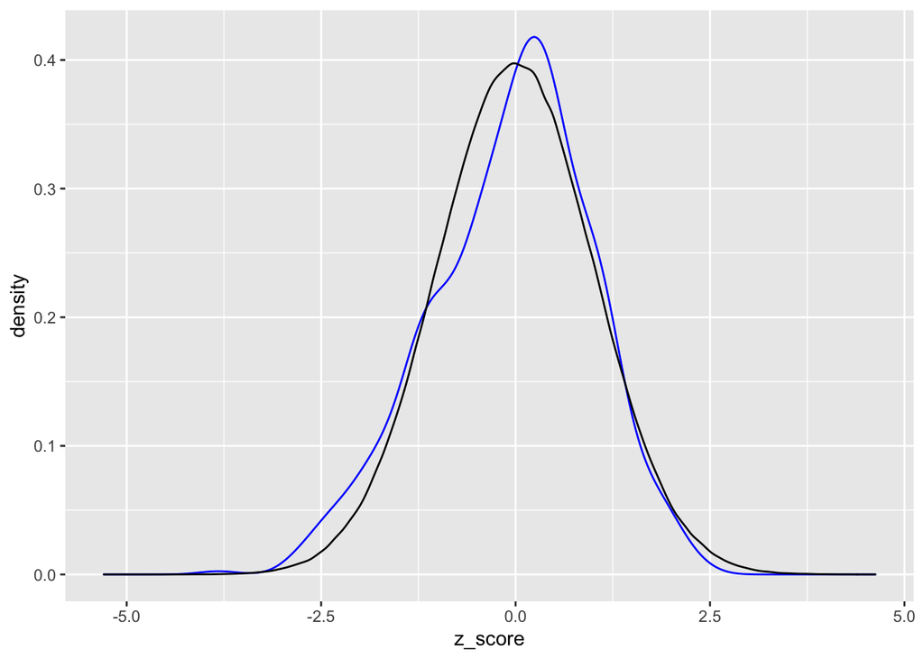

```r
map_rows <- mix_est$indiv_posteriors %>%
  group_by(indiv) %>%
  top_n(1, PofZ) %>%
  ungroup()

normo <- tibble(z_score = rnorm(1e06))
ggplot(map_rows, aes(x = z_score)) +
  geom_density(colour = "blue") +
  geom_density(data = normo, colour = "black")
```

Nice, the distribution of Z scores is normally distributed. There are no unusual z-scores in the mix that might stem from unaccounted for populations.

## Individuals Assignments

Next we take examine the individual posteriors. We will sum the posteriour probabilities within a reporting unit for each individual, then choose the most likely reporting unit as that with highest probability.

```r
#aggregate
repu_pofzs_assn <- mix_est$indiv_posteriors %>%
  group_by(indiv, repunit) %>%  # first aggregate over reporting units
  summarise(repu_PofZ = sum(PofZ)) %>%
  ungroup() %>%
  group_by(indiv) %>%
  slice_max(repu_PofZ)
```